# Big Data Midterm Exam

2024-03-28

## Problem 1

```r
# Defining the data
observations <- data.frame(
  x1 = c(2, 1, 1, 5, 3, 0, 5),
  x2 = c(2, 0, 2, 2, 2, 1, 1),
  x3 = c(2, 5, 3, 3, 8, 4, 0),
  y = c("Success", "Failure", "Failure", "Success", "Failure", "Failure", "Success")
)

new_product <- c(1, 2, 3)

# Function to calculate Manhattan distance
manhattan_distance <- function(a, b) {
  sum(abs(a - b))
}

# Function to calculate Euclidean distance
euclidean_distance <- function(a, b) {
  sqrt(sum((a - b)^2))
}

# Calculating distances
observations$manhattan <- apply(observations[1:3], 1, manhattan_distance, b = new_product)
observations$euclidean <- apply(observations[1:3], 1, euclidean_distance, b = new_product)

# Preview the updated data with distances
print(observations)
```

```
##   x1 x2 x3       y manhattan euclidean
## 1  2  2  2 Success         2  1.414214
## 2  1  0  5 Failure         4  2.828427
## 3  1  2  3 Failure         0  0.000000
## 4  5  2  3 Success         4  4.000000
## 5  3  2  8 Failure         7  5.385165
## 6  0  1  4 Failure         3  1.732051
## 7  5  1  0 Success         8  5.099020
```

## Part a

```r
# Predict function based on K-nearest neighbors
predict_knn <- function(data, k, distance_col = "manhattan") {
  sorted_data <- data[order(data[[distance_col]]), ]
  top_k <- head(sorted_data, k)
  return(names(sort(table(top_k$y), decreasing = TRUE))[1])
}

# Predictions for K = 3 and K = 5 using Manhattan distance
prediction_k3_manhattan <- predict_knn(observations, 3, "manhattan")
prediction_k5_manhattan <- predict_knn(observations, 5, "manhattan")

# Predictions for K = 3 and K = 5 using Euclidean distance
prediction_k3_euclidean <- predict_knn(observations, 3, "euclidean")
prediction_k5_euclidean <- predict_knn(observations, 5, "euclidean")
```

Both Manhattan and Euclidean distances yield the same predictions for both K=3 and K=5, with the new product being predicted as a “Failure” in both cases. This suggests that based on the nearest neighbors in the dataset, regardless of the distance metric or the number of neighbors considered, the predicted outcome for the new product remains consistent as “Failure.”

## Part b

Higher Variance: Expected with lower K values (e.g., K=3), because the model is more flexible and more closely follows the specific details (and noise) of the training data.

Higher Bias: Expected with higher K values (e.g., K=5), because the model is less flexible, potentially oversimplifying the true underlying patterns in the data by averaging more neighbors’ responses.

## Problem 3

# Part a

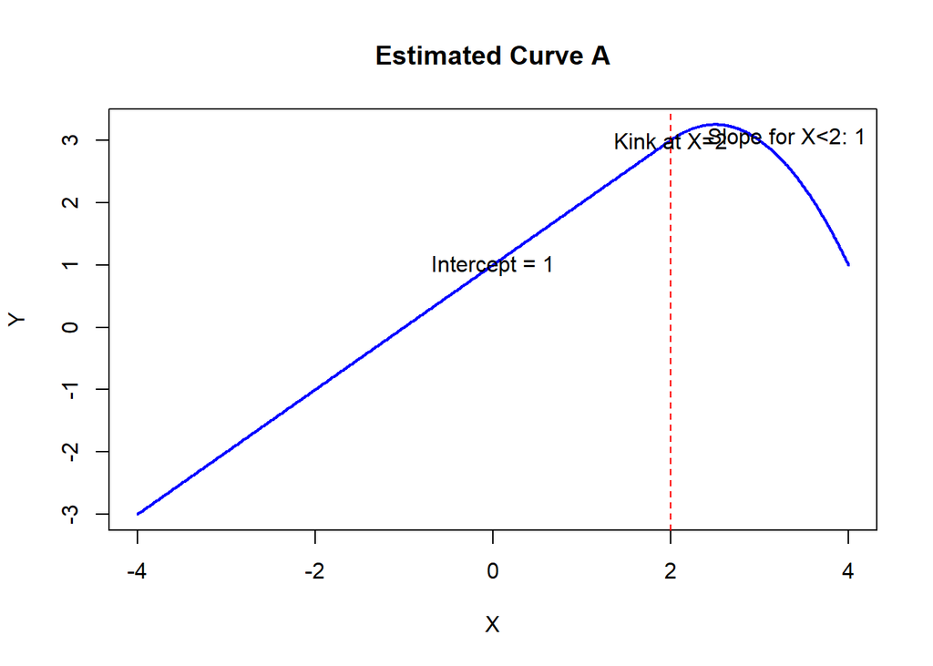

```r
# Define the parameters
beta_0 <- 1
beta_1 <- 1
beta_2 <- -1

# Create a sequence of X values from -4 to 4
X <- seq(-4, 4, by = 0.01)

# Compute the Y values based on the model
Y <- beta_0 + beta_1 * X + beta_2 * (X - 2)^2 * ifelse(X >= 2, 1, 0)

# Plot the curve
plot(X, Y, type = "l", main = "Estimated Curve A",
     xlab = "X", ylab = "Y",
     col = "blue", lwd = 2)

# Add a vertical line at X=2 to show the piecewise function change
abline(v = 2, col = "red", lty = 2)

# Add labels to indicate the piecewise sections and slopes
text(x = 0, y = beta_0, labels = paste("Intercept =", beta_0))
text(x = 2, y = beta_0 + beta_1 * 2, labels = "Kink at X=2")

# Add a legend to denote the slopes
legend("topright", legend=paste("Slope for X<2:", beta_1), bty="n")
```

## Part b

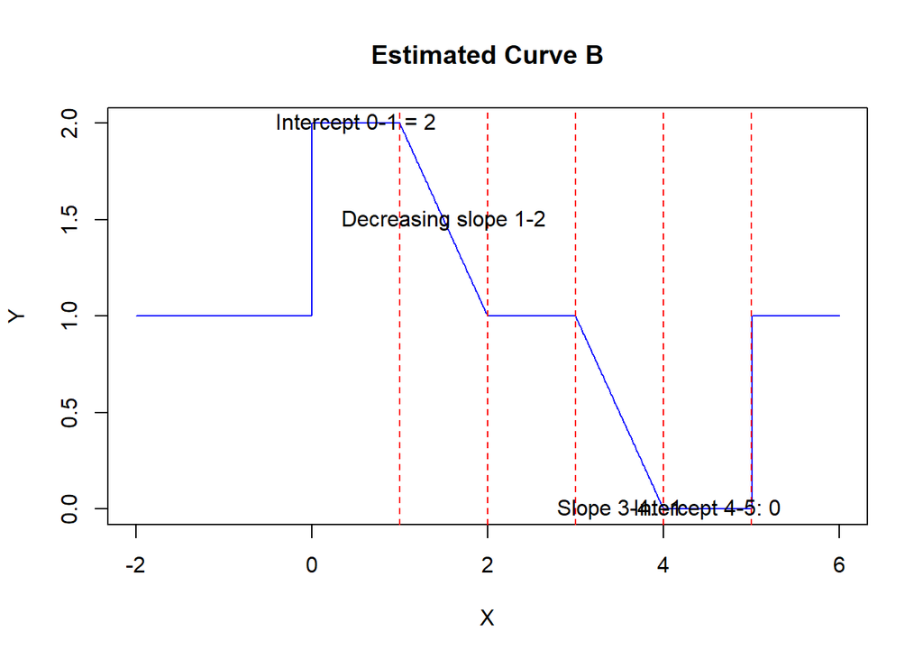

```r
# Define the function for model B
model_B <- function(x) {
  if (0 <= x & x <= 1) {
    return(beta_0 + beta_1)
  } else if (1 < x & x <= 2) {
    return(beta_0 + beta_1 * (1 - (x - 1)))
  } else if (2 < x & x <= 3) {
    return(beta_0)
  } else if (3 <= x & x <= 4) {
    return(beta_0 + beta_2 * (x - 3))
  } else if (4 < x & x <= 5) {
    return(beta_0 + beta_2)
  } else {
    return(beta_0)
  }
}

# Generate X values and compute corresponding Y values
X <- seq(-2, 6, by = 0.01)
Y <- sapply(X, model_B)

# Plot the estimated curve B
plot(X, Y, type = "l", col = "blue", xlab = "X", ylab = "Y", main = "Estimated Curve B")
abline(v = c(1, 2, 3, 4, 5), col = "red", lty = 2)  # Adding vertical lines for transition points

# Add labels to indicate the intercepts and slopes
text(x = 0.5, y = beta_0 + beta_1, labels = paste("Intercept 0-1 =", beta_0 + beta_1))
text(x = 1.5, y = beta_0 + 0.5, labels = "Decreasing slope 1-2")
text(x = 3.5, y = beta_0 + beta_2, labels = paste("Slope 3-4:", beta_2))
text(x = 4.5, y = beta_0 + beta_2, labels = paste("Intercept 4-5:", beta_0 + beta_2))
```

## Part c

(On the plots)